# Tidying your data

2016-07-15

## Using the Packages `tidyr`, `dplyr`

- Writing readable code using **pipes**
- What is **tidy data**? Why do you want tidy data? Getting your data into tidy form using tidyr.
- Reading different **data formats**
- String operations, working with **text**

## Pipes `%>%`

Pipes allow the code to be *read* like a sequence of operations

```r
student2012.sub <- readRDS("../data/student_sub.rds")
# table(student2012.sub$CNT)
student2012.sub %>% group_by(CNT) %>% tally()
```

```
#> # A tibble: 43 x 2
#>      CNT     n
#>    <chr> <int>
#> 1    ARE 11500
#> 2    AUS 14481
#> 3    AUT  4755
#> 4    BEL  8597
#> 5    BGR  5282
#> 6    BRA  5506
#> 7    CAN 21544
#> 8    CHL  6856
#> 9    COL  9073
#> 10   CZE  5327
#> # ... with 33 more rows
```

## Your turn 1

What are the variables?

| Inst | AvNumPubs | AvNumCits | PctCompletion |
| --- | --- | --- | --- |
| ARIZONA STATE UNIVERSITY | 0.90 | 1.57 | 31.7 |
| AUBURN UNIVERSITY | 0.79 | 0.64 | 44.4 |
| BOSTON COLLEGE | 0.51 | 1.03 | 46.8 |
| BOSTON UNIVERSITY | 0.49 | 2.66 | 34.2 |
| BRANDEIS UNIVERSITY | 0.30 | 3.03 | 48.7 |
| BROWN UNIVERSITY | 0.84 | 2.31 | 54.6 |

## Your turn 2

What's in the column names of this data? What are the experimental units? What are the measured variables?

| id | WI-6.R1 | WI-6.R2 | WI-6.R4 | WM-6.R1 | WM-6.R2 | WI-12.R1 | WI-12.R2 | WI-12.R4 | WM-12.R1 | WM-12.R2 | WM-12.R4 |
| --- | --- | --- | --- | --- | --- | --- | --- | --- | --- | --- | --- |
| Gene 1 | 2.182424 | 2.2042219 | 4.195636 | 2.6273345 | 5.063641 | 4.540002 | 5.534677 | 4.411520 | 3.846151 | 4.175877 | 3.7255782 |
| Gene 2 | 1.464224 | 0.5854472 | 1.859238 | 0.5152242 | 2.882808 | 1.364037 | 2.960069 | 1.309185 | 1.182724 | 1.187236 | 0.8897749 |
| Gene 3 | 2.031792 | 0.8701078 | 3.281983 | 0.5330452 | 4.627315 | 2.182192 | 5.556209 | 2.539065 | 2.539960 | 3.041293 | 1.3507193 |

## Your turn 3

What are the variables? What are the records?

```r
melbtemp <- read.fwf("../data/ASN00086282.dly",
   c(11, 4, 2, 4, rep(c(5, 1, 1, 1), 31)), fill=T)
kable(head(melbtemp[,c(1,2,3,4,seq(5,128,4))]))
```

| V1 | V2 | V3 | V4 | V5 | V9 | V13 | V17 | V21 | V25 | V29 | V33 | V37 | V41 | V45 | V49 | V53 | V57 | V61 | V65 | V69 | V73 | V77 | V81 | V85 | V89 | V93 | V97 | V101 | V105 | … |
| --- | --- | --- | --- | --- | --- | --- | --- | --- | --- | --- | --- | --- | --- | --- | --- | --- | --- | --- | --- | --- | --- | --- | --- | --- | --- | --- | --- | --- | --- | --- |
| ASN00086282 | 1970 | 7 | TMAX | 141 | 124 | 113 | 123 | 148 | 149 | 139 | 153 | 123 | 108 | 119 | 112 | 126 | 112 | 115 | 133 | 134 | 126 | 104 | 143 | 141 | 134 | 117 | 142 | 158 | 149 | … |
| ASN00086282 | 1970 | 7 | TMIN | 80 | 63 | 36 | 57 | 69 | 47 | 84 | 78 | 49 | 42 | 48 | 56 | 51 | 36 | 44 | 39 | 40 | 58 | 15 | 33 | 51 | 74 | 39 | 66 | 78 | 36 | … |
| ASN00086282 | 1970 | 7 | PRCP | 3 | 30 | 0 | 0 | 36 | 3 | 0 | 0 | 10 | 23 | 3 | 0 | 5 | 0 | 0 | 0 | 0 | 0 | 8 | 0 | 18 | 0 | 0 | 0 | 0 | 13 | … |
| ASN00086282 | 1970 | 8 | TMAX | 145 | 128 | 150 | 122 | 109 | 112 | 116 | 142 | 166 | 127 | 117 | 127 | 159 | 143 | 114 | 65 | 113 | 125 | 129 | 147 | 161 | 168 | 178 | 161 | 145 | 142 | … |
| ASN00086282 | 1970 | 8 | TMIN | 50 | 61 | 75 | 67 | 41 | 51 | 48 | -7 | 56 | 62 | 47 | 33 | 67 | 84 | 11 | 41 | 18 | 50 | 22 | 28 | 74 | 94 | 73 | 88 | 50 | 48 | … |
| ASN00086282 | 1970 | 8 | PRCP | 0 | 66 | 0 | 53 | 13 | 3 | 8 | 0 | 0 | 0 | 3 | 5 | 0 | 0 | 64 | 3 | 99 | 36 | 8 | 0 | 0 | 0 | 8 | 36 | 25 | 30 | … |

## Your turn 4

What are the variables? What are the experimental units?

```r
tb <- read_csv("../data/tb.csv")
#tail(tb)
colnames(tb)
```

```
#>  [1] "iso2"   "year"   "m_04"   "m_514"  "m_014"  "m_1524" "m_2534"
#>  [8] "m_3544" "m_4554" "m_5564" "m_65"   "m_u"    "f_04"   "f_514"
#> [15] "f_014"  "f_1524" "f_2534" "f_3544" "f_4554" "f_5564" "f_65"
#> [22] "f_u"
```

## Your turn 5

What are the variables? What are the experimental units?

```r
pew <- read.delim(
  file = "http://stat405.had.co.nz/data/pew.txt",
  header = TRUE,
  stringsAsFactors = FALSE,
  check.names = F
)
kable(pew[1:5, 1:5])
```

| religion | <$10k | $10-20k | $20-30k | $30-40k |
| --- | --- | --- | --- | --- |
| Agnostic | 27 | 34 | 60 | 81 |
| Atheist | 12 | 27 | 37 | 52 |
| Buddhist | 27 | 21 | 30 | 34 |
| Catholic | 418 | 617 | 732 | 670 |
| Don’t know/refused | 15 | 14 | 15 | 11 |

## Your turn 6

10 week sensory experiment, 12 individuals assessed taste of french fries on several scales (how potato-y, buttery, grassy, rancid, paint-y do they taste?), fried in one of 3 different oils, replicated twice. First few rows:

| time | treatment | subject | rep | potato | buttery | grassy | rancid | painty |
| --- | --- | --- | --- | --- | --- | --- | --- | --- |
| 1 | 1 | 3 | 1 | 2.9 | 0.0 | 0.0 | 0.0 | 5.5 |
| 1 | 1 | 3 | 2 | 14.0 | 0.0 | 0.0 | 1.1 | 0.0 |
| 1 | 1 | 10 | 1 | 11.0 | 6.4 | 0.0 | 0.0 | 0.0 |
| 1 | 1 | 10 | 2 | 9.9 | 5.9 | 2.9 | 2.2 | 0.0 |

What is the experimental unit? What are the factors of the experiment? What was measured? What do you want to know?

## Messy Data Patterns

There are various features of messy data that one can observe in practice. Here are some of the more commonly observed patterns.

- Column headers are values, not variable names
- Variables are stored in both rows and columns, contingency table format
- One type of experimental unit stored in multiple tables
- Dates in many different formats

## What is Tidy Data?

- Each observation forms a row
- Each variable forms a column
- Contained in a single table
- Long form makes it easier to reshape in many different ways
- Wide form is common for analysis

## Tidy Data

[figure not shown]

## Messy Data

[figure not shown]

## Tidy Verbs

- **gather**: specify the **keys** (identifiers) and the **values** (measures) to make long form (used to be called melting)
- **spread**: variables in columns (used to be called casting)
- nest/unnest: working with lists
- separate/unite: split and combine columns

## French Fries

10 week sensory experiment, 12 individuals assessed taste of french fries on several scales (how potato-y, buttery, grassy, rancid, paint-y do they taste?), fried in one of 3 different oils, replicated twice. First few rows:

| time | treatment | subject | rep | potato | buttery | grassy | rancid | painty |
| --- | --- | --- | --- | --- | --- | --- | --- | --- |
| 1 | 1 | 3 | 1 | 2.9 | 0.0 | 0.0 | 0.0 | 5.5 |
| 1 | 1 | 3 | 2 | 14.0 | 0.0 | 0.0 | 1.1 | 0.0 |
| 1 | 1 | 10 | 1 | 11.0 | 6.4 | 0.0 | 0.0 | 0.0 |
| 1 | 1 | 10 | 2 | 9.9 | 5.9 | 2.9 | 2.2 | 0.0 |
| 1 | 1 | 15 | 1 | 1.2 | 0.1 | 0.0 | 1.1 | 5.1 |
| 1 | 1 | 15 | 2 | 8.8 | 3.0 | 3.6 | 1.5 | 2.3 |

## What Would We Like to Know?

- Is the design complete?
- Are replicates like each other?
- How do the ratings on the different scales differ?
- Are raters giving different scores on average?
- Do ratings change over the weeks?

Each of these questions involves different summaries of the data.

## Gathering

- When gathering, you need to specify the **keys** (identifiers) and the **values** (measures).

Keys/Identifiers: - Identify a record (must be unique) - Example: Indices on an random variable - Fixed by design of experiment (known in advance) - May be single or composite (may have one or more variables)

Values/Measures: - Collected during the experiment (not known in advance) - Usually numeric quantities

## Gathering the French Fries

```r
ff_long <- gather(french_fries, key = variable, value =
                    rating, potato:painty)
head(ff_long)
```

```
#>   time treatment subject rep variable rating
#> 1    1         1       3   1   potato    2.9
#> 2    1         1       3   2   potato   14.0
#> 3    1         1      10   1   potato   11.0
#> 4    1         1      10   2   potato    9.9
#> 5    1         1      15   1   potato    1.2
#> 6    1         1      15   2   potato    8.8
```

## Long to Wide

In certain applications, we may wish to take a long dataset and convert it to a wide dataset (perhaps displaying in a table).

This is called "spreading" the data.

## Spread

We use the **spread** function from tidyr to do this:

```r
french_fries_wide <- spread(ff_long, key = variable,
                            value = rating)

head(french_fries_wide)
```

```
#>   time treatment subject rep buttery grassy painty potato rancid
#> 1    1         1       3   1     0.0    0.0    5.5    2.9    0.0
#> 2    1         1       3   2     0.0    0.0    0.0   14.0    1.1
#> 3    1         1      10   1     6.4    0.0    0.0   11.0    0.0
#> 4    1         1      10   2     5.9    2.9    0.0    9.9    2.2
#> 5    1         1      15   1     0.1    0.0    5.1    1.2    1.1
#> 6    1         1      15   2     3.0    3.6    2.3    8.8    1.5
```

## Answer some Questions

- Easiest question to start is whether the ratings are similar on the different scales, potato'y, buttery, grassy, rancid and painty.
- We need to gather the data into long form, and make plots facetted by the scale.

## Ratings on the Different Scales

```r
ff.m <- french_fries %>%
  gather(type, rating, -subject, -time, -treatment, -rep)
head(ff.m)
```

```
#>   time treatment subject rep   type rating
#> 1    1         1       3   1 potato    2.9
#> 2    1         1       3   2 potato   14.0
#> 3    1         1      10   1 potato   11.0
#> 4    1         1      10   2 potato    9.9
#> 5    1         1      15   1 potato    1.2
#> 6    1         1      15   2 potato    8.8
```

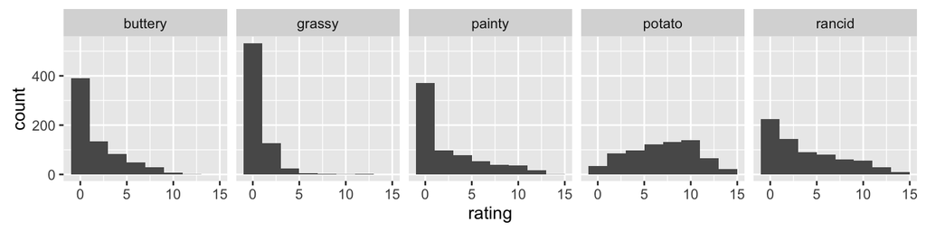

```r
ggplot(data=ff.m, aes(x=rating)) + geom_histogram(binwidth=2) +
  facet_wrap(~type, ncol=5)
```

## Side-By-Side Boxplots

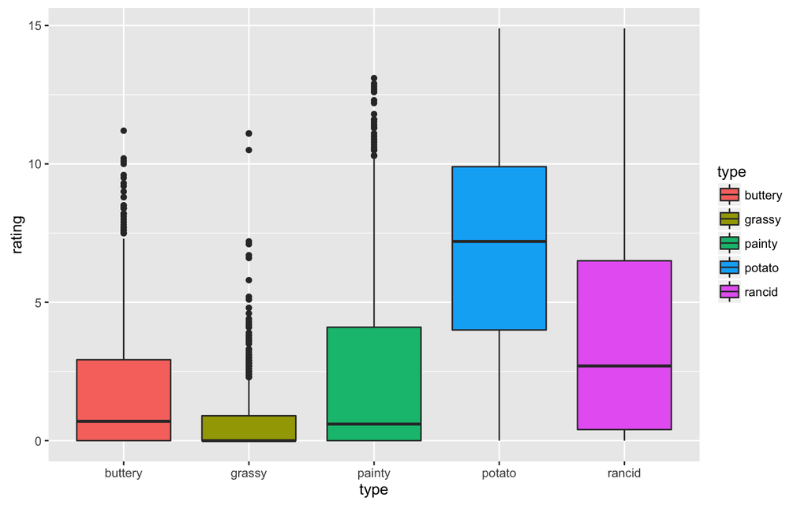

```r
ggplot(data=ff.m, aes(x=type, y=rating, fill=type)) +
  geom_boxplot()
```

## Do the Replicates Look Like Each Other?

We will start to tackle this by plotting the replicates against each other using a scatterplot.

We need to gather the data into long form, and then get the replicates spread into separate columns.

## Check Replicates

```r
head(ff.m)
```

```
#>   time treatment subject rep   type rating
#> 1    1         1       3   1 potato    2.9
#> 2    1         1       3   2 potato   14.0
#> 3    1         1      10   1 potato   11.0
#> 4    1         1      10   2 potato    9.9
#> 5    1         1      15   1 potato    1.2
#> 6    1         1      15   2 potato    8.8
```

```r
ff.s <- ff.m %>% spread(rep, rating)
head(ff.s)
```

```
#>   time treatment subject    type   1    2
#> 1    1         1       3 buttery 0.0  0.0
#> 2    1         1       3  grassy 0.0  0.0
#> 3    1         1       3  painty 5.5  0.0
#> 4    1         1       3  potato 2.9 14.0
#> 5    1         1       3  rancid 0.0  1.1
#> 6    1         1      10 buttery 6.4  5.9
```

## Check Replicates

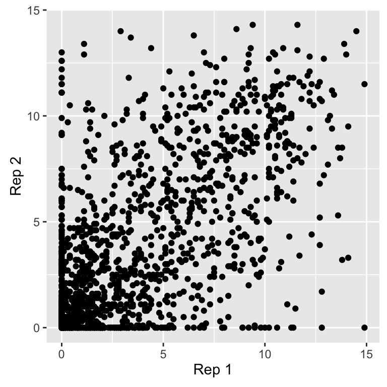

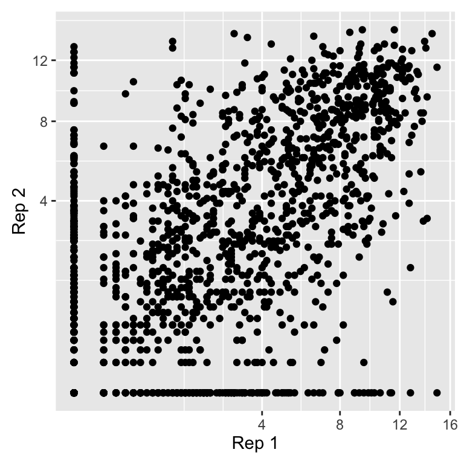

```r
ggplot(data=ff.s, aes(x=`1`, y=`2`)) + geom_point() +
  theme(aspect.ratio=1) + xlab("Rep 1") + ylab("Rep 2")
ggplot(data=ff.s, aes(x=`1`, y=`2`)) + geom_point() +
  theme(aspect.ratio=1) + xlab("Rep 1") + ylab("Rep 2") +
  scale_x_sqrt() + scale_y_sqrt()
```

## Your turn

Make the scatterplots of reps against each other separately for scales, and treatment.

## Your turn

Read in the billboard top 100 music data, which contains N'Sync and Backstreet Boys songs that entered the billboard charts in the year 2000

```r
billboard <- read.csv("../data/billboard.csv")
```

What's in this data? What's X1-X76?

## Your turn

1. Use `tidyr` to convert this data into a long format appropriate for plotting a time series (date on the x axis, chart position on the y axis)
2. Use `ggplot2` to create this time series plot:

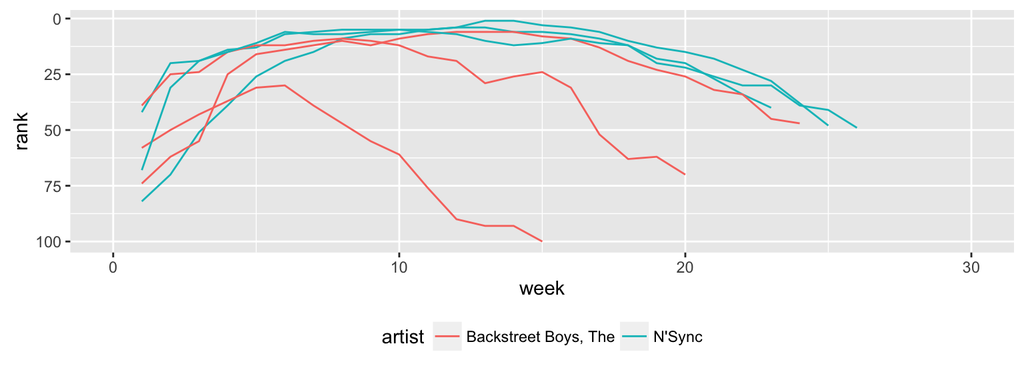

## String Manipulation

When the experimental design is packed into column names, we need to extract it, and tidy it up.

```r
genes <- read_csv("../data/genes.csv")
kable(head(genes))
```

| id | WI-6.R1 | WI-6.R2 | WI-6.R4 | WM-6.R1 | WM-6.R2 | WI-12.R1 | WI-12.R2 | WI-12.R4 | WM-12.R1 | WM-12.R2 | WM-12.R4 |
| --- | --- | --- | --- | --- | --- | --- | --- | --- | --- | --- | --- |
| Gene 1 | 2.182424 | 2.2042219 | 4.195636 | 2.6273345 | 5.063641 | 4.540002 | 5.534677 | 4.411520 | 3.846151 | 4.175877 | 3.7255782 |
| Gene 2 | 1.464224 | 0.5854472 | 1.859238 | 0.5152242 | 2.882808 | 1.364037 | 2.960069 | 1.309185 | 1.182724 | 1.187236 | 0.8897749 |
| Gene 3 | 2.031792 | 0.8701078 | 3.281983 | 0.5330452 | 4.627315 | 2.182192 | 5.556209 | 2.539065 | 2.539960 | 3.041293 | 1.3507193 |

## Gather Column Names into Long Form

```r
gather(genes, variable, expr, -id) %>% kable
```

| id | variable | expr |
| --- | --- | --- |
| Gene 1 | WI-6.R1 | 2.1824242 |
| Gene 2 | WI-6.R1 | 1.4642236 |
| Gene 3 | WI-6.R1 | 2.0317925 |
| Gene 1 | WI-6.R2 | 2.2042219 |
| Gene 2 | WI-6.R2 | 0.5854472 |
| Gene 3 | WI-6.R2 | 0.8701078 |
| Gene 1 | WI-6.R4 | 4.1956364 |
| Gene 2 | WI-6.R4 | 1.8592378 |
| Gene 3 | WI-6.R4 | 3.2819835 |
| Gene 1 | WM-6.R1 | 2.6273345 |
| Gene 2 | WM-6.R1 | 0.5152242 |
| Gene 3 | WM-6.R1 | 0.5330452 |
| Gene 1 | WM-6.R2 | 5.0636408 |
| Gene 2 | WM-6.R2 | 2.8828076 |
| Gene 3 | WM-6.R2 | 4.6273150 |
| Gene 1 | WI-12.R1 | 4.5400018 |
| Gene 2 | WI-12.R1 | 1.3640372 |
| Gene 3 | WI-12.R1 | 2.1821918 |
| Gene 1 | WI-12.R2 | 5.5346768 |
| Gene 2 | WI-12.R2 | 2.9600693 |
| Gene 3 | WI-12.R2 | 5.5562093 |
| Gene 1 | WI-12.R4 | 4.4115205 |
| Gene 2 | WI-12.R4 | 1.3091850 |
| Gene 3 | WI-12.R4 | 2.5390646 |
| Gene 1 | WM-12.R1 | 3.8461513 |
| Gene 2 | WM-12.R1 | 1.1827245 |
| Gene 3 | WM-12.R1 | 2.5399602 |
| Gene 1 | WM-12.R2 | 4.1758773 |
| Gene 2 | WM-12.R2 | 1.1872355 |
| Gene 3 | WM-12.R2 | 3.0412926 |
| Gene 1 | WM-12.R4 | 3.7255782 |
| Gene 2 | WM-12.R4 | 0.8897749 |
| Gene 3 | WM-12.R4 | 1.3507193 |

## Separate Columns

```r
genes %>%
  gather(variable, expr, -id) %>%
  separate(variable, c("trt", "leftover"), "-") %>%
  kable
```

| id | trt | leftover | expr |
| --- | --- | --- | --- |
| Gene 1 | WI | 6.R1 | 2.1824242 |
| Gene 2 | WI | 6.R1 | 1.4642236 |
| Gene 3 | WI | 6.R1 | 2.0317925 |
| Gene 1 | WI | 6.R2 | 2.2042219 |
| Gene 2 | WI | 6.R2 | 0.5854472 |
| Gene 3 | WI | 6.R2 | 0.8701078 |
| Gene 1 | WI | 6.R4 | 4.1956364 |
| Gene 2 | WI | 6.R4 | 1.8592378 |
| Gene 3 | WI | 6.R4 | 3.2819835 |
| Gene 1 | WM | 6.R1 | 2.6273345 |
| Gene 2 | WM | 6.R1 | 0.5152242 |
| Gene 3 | WM | 6.R1 | 0.5330452 |
| Gene 1 | WM | 6.R2 | 5.0636408 |
| Gene 2 | WM | 6.R2 | 2.8828076 |
| Gene 3 | WM | 6.R2 | 4.6273150 |
| Gene 1 | WI | 12.R1 | 4.5400018 |
| Gene 2 | WI | 12.R1 | 1.3640372 |
| Gene 3 | WI | 12.R1 | 2.1821918 |
| Gene 1 | WI | 12.R2 | 5.5346768 |
| Gene 2 | WI | 12.R2 | 2.9600693 |
| Gene 3 | WI | 12.R2 | 5.5562093 |
| Gene 1 | WI | 12.R4 | 4.4115205 |
| Gene 2 | WI | 12.R4 | 1.3091850 |
| Gene 3 | WI | 12.R4 | 2.5390646 |
| Gene 1 | WM | 12.R1 | 3.8461513 |
| Gene 2 | WM | 12.R1 | 1.1827245 |
| Gene 3 | WM | 12.R1 | 2.5399602 |
| Gene 1 | WM | 12.R2 | 4.1758773 |
| Gene 2 | WM | 12.R2 | 1.1872355 |
| Gene 3 | WM | 12.R2 | 3.0412926 |
| Gene 1 | WM | 12.R4 | 3.7255782 |
| Gene 2 | WM | 12.R4 | 0.8897749 |
| Gene 3 | WM | 12.R4 | 1.3507193 |

```r
genes %>%
  gather(variable, expr, -id) %>%
  separate(variable, c("trt", "leftover"), "-") %>%
  separate(leftover, c("time", "rep"), "\\.") %>% kable
```

| id | trt | time | rep | expr |
| --- | --- | --- | --- | --- |
| Gene 1 | WI | 6 | R1 | 2.1824242 |
| Gene 2 | WI | 6 | R1 | 1.4642236 |
| Gene 3 | WI | 6 | R1 | 2.0317925 |
| Gene 1 | WI | 6 | R2 | 2.2042219 |
| Gene 2 | WI | 6 | R2 | 0.5854472 |
| Gene 3 | WI | 6 | R2 | 0.8701078 |
| Gene 1 | WI | 6 | R4 | 4.1956364 |
| Gene 2 | WI | 6 | R4 | 1.8592378 |
| Gene 3 | WI | 6 | R4 | 3.2819835 |
| Gene 1 | WM | 6 | R1 | 2.6273345 |
| Gene 2 | WM | 6 | R1 | 0.5152242 |
| Gene 3 | WM | 6 | R1 | 0.5330452 |
| Gene 1 | WM | 6 | R2 | 5.0636408 |
| Gene 2 | WM | 6 | R2 | 2.8828076 |
| Gene 3 | WM | 6 | R2 | 4.6273150 |
| Gene 1 | WI | 12 | R1 | 4.5400018 |
| Gene 2 | WI | 12 | R1 | 1.3640372 |
| Gene 3 | WI | 12 | R1 | 2.1821918 |
| Gene 1 | WI | 12 | R2 | 5.5346768 |
| Gene 2 | WI | 12 | R2 | 2.9600693 |
| Gene 3 | WI | 12 | R2 | 5.5562093 |
| Gene 1 | WI | 12 | R4 | 4.4115205 |
| Gene 2 | WI | 12 | R4 | 1.3091850 |
| Gene 3 | WI | 12 | R4 | 2.5390646 |
| Gene 1 | WM | 12 | R1 | 3.8461513 |
| Gene 2 | WM | 12 | R1 | 1.1827245 |
| Gene 3 | WM | 12 | R1 | 2.5399602 |
| Gene 1 | WM | 12 | R2 | 4.1758773 |
| Gene 2 | WM | 12 | R2 | 1.1872355 |
| Gene 3 | WM | 12 | R2 | 3.0412926 |
| Gene 1 | WM | 12 | R4 | 3.7255782 |
| Gene 2 | WM | 12 | R4 | 0.8897749 |
| Gene 3 | WM | 12 | R4 | 1.3507193 |

```r
gtidy <- genes %>%
  gather(variable, expr, -id) %>%
  separate(variable, c("trt", "leftover"), "-") %>%
  separate(leftover, c("time", "rep"), "\\.") %>%
  mutate(trt = sub("W", "", trt)) %>%
  mutate(rep = sub("R", "", rep))
kable(head(gtidy))
```

| id | trt | time | rep | expr |
| --- | --- | --- | --- | --- |
| Gene 1 | I | 6 | 1 | 2.1824242 |
| Gene 2 | I | 6 | 1 | 1.4642236 |
| Gene 3 | I | 6 | 1 | 2.0317925 |
| Gene 1 | I | 6 | 2 | 2.2042219 |
| Gene 2 | I | 6 | 2 | 0.5854472 |
| Gene 3 | I | 6 | 2 | 0.8701078 |

## Your turn

1. Using the tidied dataset (`gtidy`), find the mean expression for each combination of id, trt, and time.
2. Use this tidied data to make this plot.

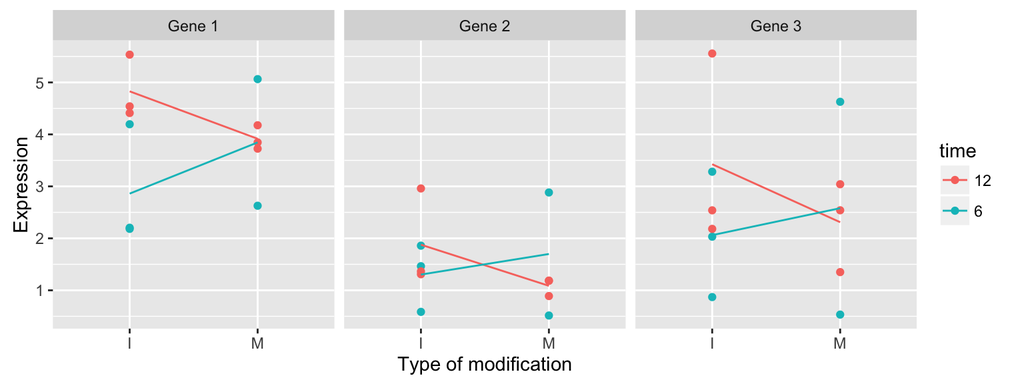

## Tidying model output

The package `broom` gets model results into a tidy format.

```r
ff_long <- gather(french_fries, key = variable, value =
                    rating, potato:painty)
ff_lm <- lm(rating~variable+treatment+time+subject,
            data=ff_long)
head(residuals(ff_lm))
```

```
#>         1         2         3         4         5         6
#> -3.431728  7.668272  2.953765  1.853765 -4.772622  2.827378
```

## Model estimates

```r
ff_lm_tidy <- tidy(ff_lm)
glimpse(ff_lm_tidy)
```

```
#> Observations: 27
#> Variables: 5
#> $ term      <chr> "(Intercept)", "variablegrassy", "variablepainty", "...
#> $ estimate  <dbl> 1.19851228, -1.15513007, 0.70054547, 5.13321525, 2.0...
#> $ std.error <dbl> 0.2579150, 0.1557200, 0.1557749, 0.1557200, 0.155720...
#> $ statistic <dbl> 4.64692727, -7.41799461, 4.49716394, 32.96439433, 13...
#> $ p.value   <dbl> 3.495385e-06, 1.489614e-13, 7.113736e-06, 2.275767e-...
```

## Model diagnostics

```r
ff_lm_all <- augment(ff_lm)
glimpse(ff_lm_all)
```

```
#> Observations: 3,471
#> Variables: 13
#> $ .rownames  <chr> "1", "2", "3", "4", "5", "6", "7", "8", "9", "10", ...
#> $ rating     <dbl> 2.9, 14.0, 11.0, 9.9, 1.2, 8.8, 9.0, 8.2, 7.0, 13.0...
#> $ variable   <chr> "potato", "potato", "potato", "potato", "potato", "...
#> $ treatment  <fctr> 1, 1, 1, 1, 1, 1, 1, 1, 1, 1, 1, 1, 1, 1, 1, 1, 1,...
#> $ time       <fctr> 1, 1, 1, 1, 1, 1, 1, 1, 1, 1, 1, 1, 1, 1, 1, 1, 1,...
#> $ subject    <fctr> 3, 3, 10, 10, 15, 15, 16, 16, 19, 19, 31, 31, 51, ...
#> $ .fitted    <dbl> 6.331728, 6.331728, 8.046235, 8.046235, 5.972622, 5...
#> $ .se.fit    <dbl> 0.2578966, 0.2578966, 0.2523712, 0.2523712, 0.25301...
#> $ .resid     <dbl> -3.4317275, 7.6682725, 2.9537651, 1.8537651, -4.772...
#> $ .hat       <dbl> 0.007910376, 0.007910376, 0.007575050, 0.007575050,...
#> $ .sigma     <dbl> 2.899486, 2.897111, 2.899641, 2.899907, 2.898931, 2...
#> $ .cooksd    <dbl> 4.169299e-04, 2.081769e-03, 2.955862e-04, 1.164238e...
#> $ .std.resid <dbl> -1.1882021, 2.6550643, 1.0225395, 0.6417396, -1.652...
```

## Residual plot

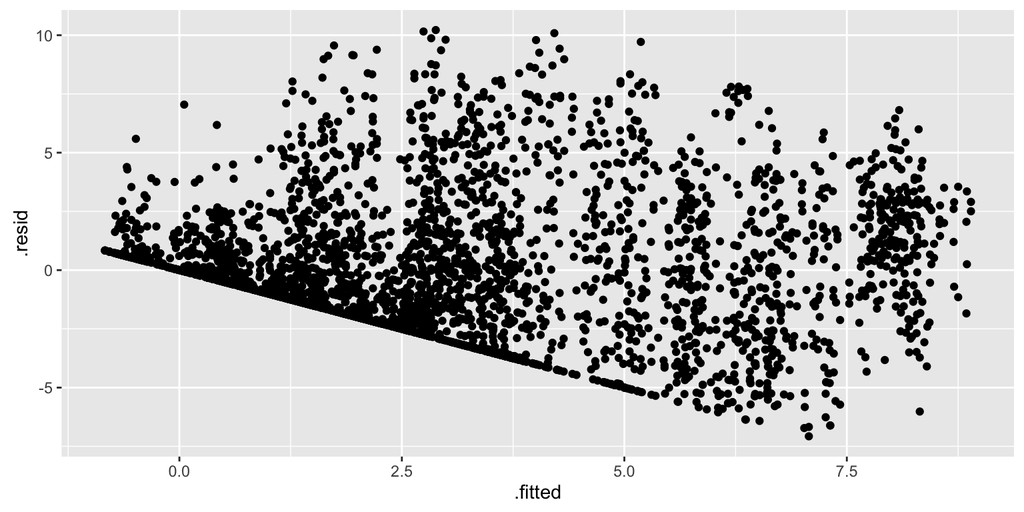

```r
ggplot(ff_lm_all, aes(x=.fitted, y=.resid)) + geom_point()
```

## Back to autism

Fit a random slopes model to the data:

\[vsae = \beta_0 + \beta_1 age2 + b_1 childid + \varepsilon\]

```r
library(lme4)
data(autism)
autism_keep <- autism %>% group_by(childid) %>%
  tally(sort=TRUE) %>% filter(n>2)
autism_sub <- autism %>%
  filter(childid %in% autism_keep$childid)
autism_lmer <- lmer(vsae ~ age2 + ( age2 - 1 | childid ),
                    data = autism_sub)
```

## Your turn

- Augment the autism data with the model diagnostics
- Plot the residuals from the (a) fixed, (b) random effects
- Color the residuals by (a) gender, (b) besttest2
- Plot fitted values against observed values

## Resources

- [tidyr and dplyr cheatsheet](http://www.rstudio.com/wp-content/uploads/2015/02/data-wrangling-cheatsheet.pdf)
- [Wickham (2007) Reshaping data](https://www.jstatsoft.org/article/view/v021i12/v21i12.pdf)
- [broom vignettes, David Robinson](https://cran.r-project.org/web/packages/broom/vignettes/broom.html)

## Share and share alike

This work is licensed under the Creative Commons Attribution-Noncommercial 3.0 United States License. To view a copy of this license, visit http://creativecommons.org/licenses/by-nc/ 3.0/us/ or send a letter to Creative Commons, 171 Second Street, Suite 300, San Francisco, California, 94105, USA.